# Figure S14

GSEA for gene signatures associated with demographic and clinical factors at W0

# 1 Introduction

GSEA analyses correlate NanoString gene expression with demographic and clinical factors at W0. Variables analysed are Age, Sex, BMI, Previous TB history, W0 Mtb burden (MGIT_0), and Mtb lineage. Genes are ranked by the limma t-statistic from a linear regression of expression against each variable, adjusted for covariates. Age is adjusted for Sex and trial Arm only. Sex is adjusted for Age and trial Arm only. All other variables are adjusted for Age, Sex, and trial Arm.

NanoTube `limmaToFGSEA` with a combined gene set of NanoString panel annotations and the Hallmark collection is the primary analysis. Significance threshold: FDR < 0.01 and absolute NES > 1.0.

PLAGE is used for validation. The two methods ask fundamentally different questions. NanoTube detects enrichment from many genes with small effects, while PLAGE requires the first principal component of pathway genes to align with the variable, which is less likely for weak demographic signals. Poor overlap between the two methods is therefore expected and does not indicate that either result is incorrect. Significant NanoTube findings are reported in supplemental figures and should be interpreted with caution.

# 2 Load packages

```r
library(readxl)
library(readr)
library(DataExplorer)
library(dplyr)
library(tidyr)
library(ggplot2)
library(limma)
library(fgsea)
library(msigdbr)
library(writexl)
library(Biobase)
library(NanoTube)
```

# 3 Define file paths

```r
input_nano    <- "Input/Nanostring_Wide_log2_normalised.xlsx"
input_annot   <- "Input/NanoString_ProbeAnnotations_NS_Hs_HostResponse_v1.1_panel.csv"
input_lineage <- "Input/Demographic and clinical information.xlsx"
output_main   <- "Output/Figure_S14"

dir.create(output_main, recursive = TRUE, showWarnings = FALSE)
```

# 4 Load data

```r
all_data <- read_excel(input_nano, sheet = 1)
head(all_data)
```

```
# A tibble: 6 × 843
  Barcode   Donor Visit Stimulation Comments   ACE ACKR2 ACKR3 ACKR4 ACOX1 ACSL1
  <chr>     <chr> <chr> <chr>       <chr>    <dbl> <dbl> <dbl> <dbl> <dbl> <dbl>
1 04082179… 31    0     TB          success      0     0     0  0     7.65  13.0
2 04082180… 34    0     NULL        success      0     0     0  0     8.80  12.4
3 04082180… 54    16    TB          success      0     0     0  0     8.30  11.4
4 04082302… 19    0     NULL        success      0     0     0  2.35 10.8   14.0
5 04082302… 23    16    TB          success      0     0     0  1.19  9.01  11.8
6 04082303… 25    0     NULL        treatme…     0     0     0  4.21  9.10  12.9
# ℹ 832 more variables: ACSL3 <dbl>, ACSL4 <dbl>, ACTA2 <dbl>, ACVR1 <dbl>,
#   ADAR <dbl>, ADGRE5 <dbl>, ADGRG3 <dbl>, ADORA2A <dbl>, AGT <dbl>,
#   AHR <dbl>, AIF1 <dbl>, AIM2 <dbl>, AKT1 <dbl>, AKT2 <dbl>, AKT3 <dbl>,
#   ALDH1A1 <dbl>, ALOX12 <dbl>, ALOX15 <dbl>, ALOX5 <dbl>, ALOX5AP <dbl>,
#   ALPK1 <dbl>, ALPL <dbl>, ANKRD22 <dbl>, ANPEP <dbl>, AP1G1 <dbl>,
#   AP1M1 <dbl>, AP1S2 <dbl>, APBB1IP <dbl>, APEX1 <dbl>, APOBEC3G <dbl>,
#   APOL1 <dbl>, APOL6 <dbl>, APP <dbl>, ARRB2 <dbl>, ATF2 <dbl>, ATF4 <dbl>, …
```

```r
dim(all_data)
```

```
[1] 286 843
```

```r
lineage_data <- read_excel(input_lineage, sheet = 1) %>%
  rename(Donor = ID1) %>%
  select(Donor, main_lineage)

head(lineage_data)
```

```
# A tibble: 6 × 2
  Donor      main_lineage
  <chr>      <chr>
1 PD-1-2-014 lineage4
2 PD-1-2-015 lineage4
3 PD-1-2-016 lineage4
4 PD-1-2-017 lineage4
5 PD-1-2-019 lineage4
6 PD-1-2-020 lineage2
```

```r
dim(lineage_data)
```

```
[1] 40  2
```

# 5 Filter and recode

One barcode (0408230288) is excluded as a quality control outlier. Stimulation labels are standardised. Previous TB history is recoded from the original category label to a binary Yes/No factor. Clinical and demographic variables are typed correctly before analysis.

```r
nano_data <- all_data %>%
  filter(Comments == "success") %>%
  mutate(
    Stimulation = ifelse(Stimulation == "TB",   "Mtb_Ag", Stimulation),
    Stimulation = ifelse(Stimulation == "NULL", "Null",   Stimulation),
    Visit       = paste0("W", Visit),
    Previous_TB = ifelse(Previous_TB == "0 episode", "No", "Yes")
  ) %>%
  filter(!Barcode %in% "0408230288") %>%
  select(-Barcode)

cat(sprintf("Rows: %d | Columns: %d\n", nrow(nano_data), ncol(nano_data)))
```

```
Rows: 231 | Columns: 842
```

```r
cat(sprintf("Visits: %s\n",       paste(unique(nano_data$Visit),       collapse = ", ")))
```

```
Visits: W0, W16
```

```r
cat(sprintf("Stimulations: %s\n", paste(unique(nano_data$Stimulation), collapse = ", ")))
```

```
Stimulations: Mtb_Ag, Null, IL1B, LPS
```

```r
cat(sprintf("Previous_TB values: %s\n",
            paste(sort(unique(nano_data$Previous_TB)), collapse = ", ")))
```

```
Previous_TB values: No, Yes
```

# 6 Data overview

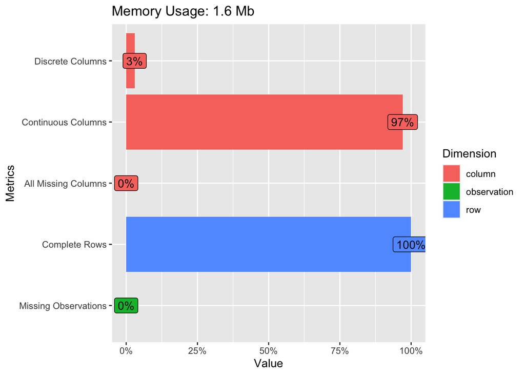

```r
plot_intro(nano_data)
```

# 7 Merge NanoString and lineage data

The Donor ID prefix is stripped from the lineage data to match the format used in the NanoString data before joining.

```r
lineage_data$Donor <- sub("^PD-1-2-0", "", lineage_data$Donor)

nano_lineage_data <- nano_data %>%
  left_join(lineage_data, by = "Donor") %>%
  mutate(
    Age          = as.numeric(Age),
    BMI_0        = as.numeric(BMI_0),
    MGIT_0       = as.numeric(MGIT_0),
    Sex          = factor(Sex,          levels = c("Male", "Female")), # Male as the reference
    Arm          = factor(Arm,          levels = c("A", "B", "C")),
    Previous_TB  = factor(Previous_TB,  levels = c("No", "Yes")), # No as the reference
    main_lineage = factor(main_lineage, levels = c("lineage2", "lineage4")) # lineage2 as the reference
  )

cat(sprintf("Merged rows: %d | Columns: %d\n",
            nrow(nano_lineage_data), ncol(nano_lineage_data)))
```

```
Merged rows: 231 | Columns: 843
```

```r
cat(sprintf("Lineage values: %s\n",
            paste(sort(unique(nano_lineage_data$main_lineage)), collapse = ", ")))
```

```
Lineage values: lineage2, lineage4
```

```r
cat(sprintf(
  "Covariate check - Age range: %.0f - %.0f | Sex: %s | Arm: %s\n",
  min(nano_lineage_data$Age, na.rm = TRUE),
  max(nano_lineage_data$Age, na.rm = TRUE),
  paste(levels(nano_lineage_data$Sex), collapse = ", "),
  paste(levels(nano_lineage_data$Arm), collapse = ", ")
))
```

```
Covariate check - Age range: 19 - 62 | Sex: Male, Female | Arm: A, B, C
```

# 8 Check clinical variables are present

```r
clinical_vars <- c("Age", "Sex", "BMI_0", "Previous_TB", "MGIT_0", "main_lineage")

for (v in clinical_vars) {
  n_non_na <- sum(!is.na(nano_lineage_data[[v]]))
  cat(sprintf("  %-15s: %d non-NA values\n", v, n_non_na))
}
```

```
  Age            : 231 non-NA values
  Sex            : 231 non-NA values
  BMI_0          : 231 non-NA values
  Previous_TB    : 231 non-NA values
  MGIT_0         : 231 non-NA values
  main_lineage   : 231 non-NA values
```

# 9 Define gene columns

Gene columns run from ACE to TBP. A guard check stops the document if either boundary column is missing.

```r
col_start <- which(names(nano_data) == "ACE")
col_end   <- which(names(nano_data) == "TBP")

if (length(col_start) == 0 || length(col_end) == 0) {
  stop("ACE or TBP not found in nano_data. Check column names.")
}

gene_cols <- names(nano_data)[col_start:col_end]

cat(sprintf(
  "First gene: %s | Last gene: %s | Total: %d\n",
  names(nano_data)[col_start],
  names(nano_data)[col_end],
  length(gene_cols)
))
```

```
First gene: ACE | Last gene: TBP | Total: 815
```

# 10 Load NanoString pathway annotations

The NanoString immune panel includes its own pathway annotations for each probe. The annotation column uses :: as a separator between multiple pathway assignments.

```r
probe_annot <- read_csv(input_annot, show_col_types = FALSE)

nanostring_pathway_df <- probe_annot %>%
  filter(Is.Control == 0,
         !is.na(Probe.Annotation),
         Probe.Annotation != "") %>%
  select(Gene = Probe.Label, Pathway = Probe.Annotation) %>%
  separate_rows(Pathway, sep = "::") %>%
  filter(!is.na(Pathway), Pathway != "")

nanostring_pathways <- split(nanostring_pathway_df$Gene,
                             nanostring_pathway_df$Pathway)

cat(sprintf("NanoString-defined pathways: %d\n", length(nanostring_pathways)))
```

```
NanoString-defined pathways: 56
```

```r
pathway_coverage <- sapply(nanostring_pathways, function(g) sum(g %in% gene_cols))
cat(sprintf(
  "Pathways with at least 3 genes measured: %d / %d\n",
  sum(pathway_coverage >= 3),
  length(nanostring_pathways)
))
```

```
Pathways with at least 3 genes measured: 56 / 56
```

# 11 Load Hallmark gene sets

Only Hallmark gene sets with at least 3 genes measured in this panel are retained to avoid testing pathways with minimal representation.

```r
hallmark <- msigdbr(species = "Homo sapiens", collection = "H") %>%
  select(gs_name, gene_symbol)

hallmark_list <- split(hallmark$gene_symbol, hallmark$gs_name)

hallmark_filtered <- hallmark_list[
  sapply(hallmark_list, function(g) sum(g %in% gene_cols) >= 3)
]

cat(sprintf(
  "Hallmark gene sets with at least 3 genes measured: %d / %d\n",
  length(hallmark_filtered),
  length(hallmark_list)
))
```

```
Hallmark gene sets with at least 3 genes measured: 46 / 50
```

# 12 Build combined pathway set

NanoString panel annotations are merged with the filtered Hallmark collection. Duplicate names are removed.

```r
combined_pathways <- c(nanostring_pathways, hallmark_filtered)
combined_pathways <- combined_pathways[!duplicated(names(combined_pathways))]

cat(sprintf(
  "Combined pathway set: %d NanoString + %d Hallmark = %d total\n",
  length(nanostring_pathways),
  length(hallmark_filtered),
  length(combined_pathways)
))
```

```
Combined pathway set: 56 NanoString + 46 Hallmark = 102 total
```

# 13 Analysis configuration

Each entry specifies the variable of interest, the exact coefficient name that model.matrix will produce for that variable, the covariates to include, and whether the variable is continuous or binary. Binary variables are converted to numeric 0/1 for the PLAGE Pearson correlation test.

```r
analysis_config <- list(

  Age = list(
    visit        = "W0",
    variable     = "Age",
    coef_name    = "Age",
    label        = "Age (years)",
    covariates   = c("Sex", "Arm"),
    var_type     = "continuous",
    positive_label = "higher Age",
    negative_label = "lower Age",
    min_n        = 10,
    top_n_enrich = 5
  ),

  Sex = list(
  visit        = "W0",
  variable     = "Sex",
  coef_name    = "SexFemale",
  label        = "Sex",
  covariates   = c("Age", "Arm"),
  var_type     = "binary",
  positive_label = "Female",
  negative_label = "Male",
  min_n        = 10,
  top_n_enrich = 5
),

  BMI = list(
    visit        = "W0",
    variable     = "BMI_0",
    coef_name    = "BMI_0",
    label        = "BMI at W0",
    covariates   = c("Age", "Sex", "Arm"),
    var_type     = "continuous",
    positive_label = "higher BMI",
    negative_label = "lower BMI",
    min_n        = 10,
    top_n_enrich = 5
  ),

  Previous_TB = list(
    visit        = "W0",
    variable     = "Previous_TB",
    coef_name    = "Previous_TBYes",
    label        = "Previous TB history",
    covariates   = c("Age", "Sex", "Arm"),
    var_type     = "binary",
    positive_label = "Previous TB (Yes)",
    negative_label = "Previous TB (No)",
    min_n        = 10,
    top_n_enrich = 5
  ),

  MGIT = list(
    visit        = "W0",
    variable     = "MGIT_0",
    coef_name    = "MGIT_0",
    label        = "MGIT time to positivity at W0 (days)",
    covariates   = c("Age", "Sex", "Arm"),
    var_type     = "continuous",
    positive_label = "higher MGIT",
    negative_label = "lower MGIT",
    min_n        = 10,
    top_n_enrich = 5
  ),

  Lineage = list(
    visit        = "W0",
    variable     = "main_lineage",
    coef_name    = "main_lineagelineage4",
    label        = "Mtb lineage",
    covariates   = c("Age", "Sex", "Arm"),
    var_type     = "binary",
    positive_label = "Lineage 4",
    negative_label = "Lineage 2",
    min_n        = 10,
    top_n_enrich = 5
  )
)
```

# 14 limma functions

`prepare_limma_continuous`: filters to a given visit and stimulation, removes rows with missing values for the variable of interest and its covariates, and returns an expression matrix and metadata ready for limma.

```r
prepare_limma_continuous <- function(data, stimulation, visit,
                                     variable, gene_cols,
                                     covariates = c("Age", "Sex", "Arm"),
                                     min_n = 10) {

  filter_vars <- unique(c(variable, covariates))

  stim_data <- data %>%
    filter(Stimulation == stimulation, Visit == visit)

  for (v in filter_vars) {
    stim_data <- stim_data %>% filter(!is.na(.data[[v]]))
  }

  n <- nrow(stim_data)
  cat(sprintf("  %s | %s | %s: n = %d", stimulation, visit, variable, n))

  if (n < min_n) {
    cat(sprintf(" -- skipping (fewer than %d samples)\n", min_n))
    return(NULL)
  }

  cat(sprintf(" | n after filtering: %d\n", n))

  expr_matrix           <- t(as.matrix(stim_data[, gene_cols]))
  colnames(expr_matrix) <- paste0("S", seq_len(ncol(expr_matrix)))

  keep_cols       <- unique(c("Donor", variable, covariates))
  metadata        <- stim_data[, keep_cols, drop = FALSE]
  metadata$Sample <- colnames(expr_matrix)

  cat(sprintf("  Expression matrix: %d genes x %d samples\n",
              nrow(expr_matrix), ncol(expr_matrix)))

  list(expr_matrix = expr_matrix, metadata = metadata)
}
```

`run_limma_continuous`: fits `Expression ~ variable + covariates` per gene. The exact coefficient name to extract is passed from the config because binary factors generate compound names in model.matrix.

```r
run_limma_continuous <- function(expr_matrix, metadata, variable,
                                  coef_name,
                                  covariates = c("Age", "Sex", "Arm")) {

  covariate_str <- paste(covariates, collapse = " + ")
  formula_str   <- paste("~", variable, "+", covariate_str)
  design        <- model.matrix(as.formula(formula_str), data = metadata)

  gene_vars   <- apply(expr_matrix, 1, var)
  n_removed   <- sum(gene_vars == 0)
  expr_matrix <- expr_matrix[gene_vars > 0, ]
  if (n_removed > 0) cat(sprintf("  Removed %d zero-variance genes\n", n_removed))

  if (!coef_name %in% colnames(design)) {
    cat(sprintf("  Coefficient '%s' not found. Available: %s\n",
                coef_name, paste(colnames(design), collapse = ", ")))
    return(NULL)
  }

  fit     <- lmFit(expr_matrix, design)
  fit     <- eBayes(fit)
  results <- topTable(fit, coef = coef_name, number = Inf, sort.by = "none")
  results$Gene <- rownames(results)

  ranked_genes <- sort(setNames(results$t, results$Gene), decreasing = TRUE)

  cat(sprintf(
    "  Genes: %d | FDR < 0.05: %d | FDR < 0.01: %d | t range: [%.2f, %.2f]\n",
    nrow(results),
    sum(results$adj.P.Val < 0.05, na.rm = TRUE),
    sum(results$adj.P.Val < 0.01, na.rm = TRUE),
    min(results$t), max(results$t)
  ))

  list(fit = fit, ranked_genes = ranked_genes, results = results)
}
```

# 15 PLAGE validation function

`run_plage_continuous`: for each pathway, gene expression is mean-centred and decomposed by SVD. The first right singular vector gives a per-sample pathway activity score. The score is correlated with the variable using Pearson correlation without covariate adjustment. Binary factor variables are converted to numeric 0/1 before the correlation test. FDR correction is applied across all pathways within each stimulation condition.

```r
run_plage_continuous <- function(data, stimulation, visit, variable,
                                  pathway_name, gene_set, min_n = 10) {

  available_genes <- intersect(gene_set, names(data))
  if (length(available_genes) < 3) return(NULL)

  stim_data <- data %>%
    filter(Stimulation == stimulation,
           Visit == visit,
           !is.na(.data[[variable]]))

  if (nrow(stim_data) < min_n) return(NULL)

  expr_mat      <- t(as.matrix(stim_data[, available_genes]))
  expr_mat      <- expr_mat - rowMeans(expr_mat)
  svd_res       <- svd(expr_mat)
  sample_scores <- svd_res$v[, 1]

  if (cor(sample_scores, colMeans(expr_mat)) < 0) {
    sample_scores <- -sample_scores
  }

  var_vals <- stim_data[[variable]]

  if (is.factor(var_vals)) {
    var_vals <- as.numeric(var_vals) - 1
  }

  test <- tryCatch(
    cor.test(sample_scores, var_vals, method = "pearson"),
    error = function(e) NULL
  )

  if (is.null(test)) return(NULL)

  data.frame(
    Pathway     = pathway_name,
    Stimulation = stimulation,
    Visit       = visit,
    Variable    = variable,
    N_genes     = length(available_genes),
    N_samples   = nrow(stim_data),
    Score_cor   = as.numeric(test$estimate),
    t_statistic = as.numeric(test$statistic),
    P_value     = test$p.value,
    stringsAsFactors = FALSE
  )
}
```

# 16 Bubble plot function

Symmetric colour limits are computed automatically so the midpoint white always maps to zero regardless of whether all values have the same sign.

```r
plot_bubble <- function(plot_data, title, subtitle, save_path, filename,
                        x_col = "pathway_short", fill_col = "NES",
                        fill_name = "NES") {

  if (nrow(plot_data) == 0) {
    cat("No pathways to plot. Skipping bubble plot.\n")
    return(invisible(NULL))
  }

  fill_limit <- max(abs(plot_data[[fill_col]]), na.rm = TRUE)
  fill_limit <- ceiling(fill_limit * 10) / 10

  pathway_order <- plot_data %>%
    arrange(.data[["padj_plot"]]) %>%
    pull(.data[[x_col]]) %>%
    unique()

  plot_data <- plot_data %>%
    mutate(
      !!x_col    := factor(.data[[x_col]], levels = pathway_order),
      Stimulation = factor(Stimulation, levels = c("Null", "Mtb_Ag", "LPS", "IL1B"))
    )

  p <- ggplot(
      plot_data,
      aes(x = .data[[x_col]], y = Stimulation,
          size = -log10(padj_plot), color = .data[[fill_col]])
    ) +
    geom_point(alpha = 0.8) +
    scale_color_gradient2(
      low      = "blue",
      mid      = "white",
      high     = "red",
      midpoint = 0,
      limits   = c(-fill_limit, fill_limit),
      name     = fill_name
    ) +
    scale_size_continuous(range = c(3, 10), name = "-log10(FDR)") +
    scale_x_discrete(drop = FALSE) +
    scale_y_discrete(drop = FALSE) +
    labs(title = title, subtitle = subtitle, x = "Pathway", y = "Stimulation") +
    theme_classic(base_size = 12) +
    theme(
      axis.text.x      = element_text(angle = 45, hjust = 1, color = "black", size = 8),
      axis.text.y      = element_text(color = "black"),
      panel.grid.major = element_line(color = "gray90"),
      legend.position  = "right"
    )

  print(p)

  ggsave(
    file.path(save_path, filename),
    plot = p, width = 9.5, height = 6, units = "in"
  )

  invisible(p)
}
```

# 17 Enrichment plot function

```r
plot_enrichment <- function(ranked_list, pathway_name,
                            combined_pathways, stimulation, variable,
                            nes, padj, save_path) {

  gene_set <- combined_pathways[[pathway_name]]
  if (is.null(gene_set)) return(invisible(NULL))

  clean_name <- gsub("HALLMARK_", "Hallmark: ", pathway_name)
  clean_name <- gsub("_", " ", clean_name)

  p <- plotEnrichment(gene_set, ranked_list) +
    labs(
      title    = clean_name,
      subtitle = sprintf("%s | %s | NES = %.2f | FDR = %.2e",
                         stimulation, variable, nes, padj),
      x = "Gene rank",
      y = "Enrichment score"
    ) +
    theme_classic(base_size = 12) +
    theme(
      plot.title    = element_text(face = "bold", size = 11),
      plot.subtitle = element_text(size = 9, color = "gray40"),
      panel.border  = element_rect(color = "black", fill = NA)
    )

  print(p)

  safe_name <- substr(gsub("[^a-zA-Z0-9]", "_", pathway_name), 1, 50)
  ggsave(
    file.path(save_path, paste0(stimulation, "_", safe_name, "_enrichment.pdf")),
    plot = p, width = 7, height = 5, units = "in"
  )

  invisible(p)
}
```

# 18 Run all analyses

For each demographic or clinical variable, limma is run per stimulation to produce ranked gene lists. NanoTube `limmaToFGSEA` is run as the primary analysis and PLAGE as the validation. Due to the weak and diffuse nature of demographic signals, limited overlap between the two methods is expected and acknowledged.

```
Analysis: Age | Variable: Age | Visit: W0
  Mtb_Ag | W0 | Age: n = 32 | n after filtering: 32
  Expression matrix: 815 genes x 32 samples
  Removed 75 zero-variance genes
  Genes: 740 | FDR < 0.05: 0 | FDR < 0.01: 0 | t range: [-3.07, 3.80]
  Null | W0 | Age: n = 31 | n after filtering: 31
  Expression matrix: 815 genes x 31 samples
  Removed 84 zero-variance genes
  Genes: 731 | FDR < 0.05: 1 | FDR < 0.01: 0 | t range: [-4.95, 2.47]
  IL1B | W0 | Age: n = 32 | n after filtering: 32
  Expression matrix: 815 genes x 32 samples
  Removed 63 zero-variance genes
  Genes: 752 | FDR < 0.05: 0 | FDR < 0.01: 0 | t range: [-3.94, 3.45]
  LPS | W0 | Age: n = 31 | n after filtering: 31
  Expression matrix: 815 genes x 31 samples
  Removed 69 zero-variance genes
  Genes: 746 | FDR < 0.05: 0 | FDR < 0.01: 0 | t range: [-2.59, 2.97]
  NanoTube GSEA (primary): Mtb_Ag
```

```
    Significant pathways (FDR < 0.01 and |NES| > 1): 0
  NanoTube GSEA (primary): Null
```

```
    Significant pathways (FDR < 0.01 and |NES| > 1): 1
  NanoTube GSEA (primary): IL1B
```

```
    Significant pathways (FDR < 0.01 and |NES| > 1): 0
  NanoTube GSEA (primary): LPS
```

```
    Significant pathways (FDR < 0.01 and |NES| > 1): 0
```

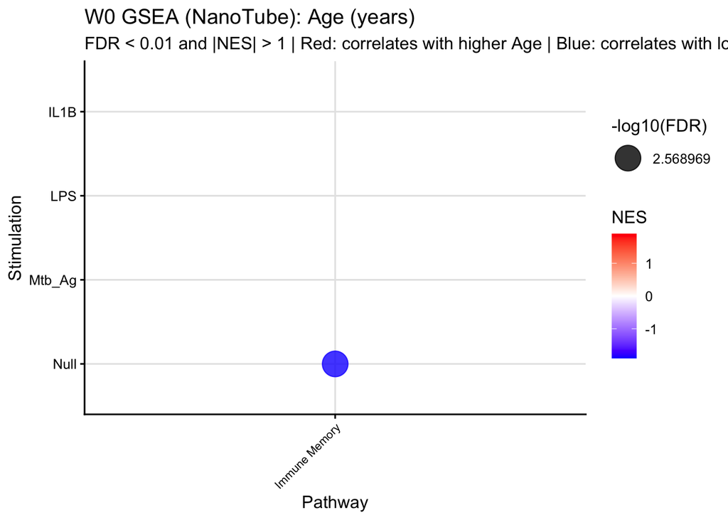

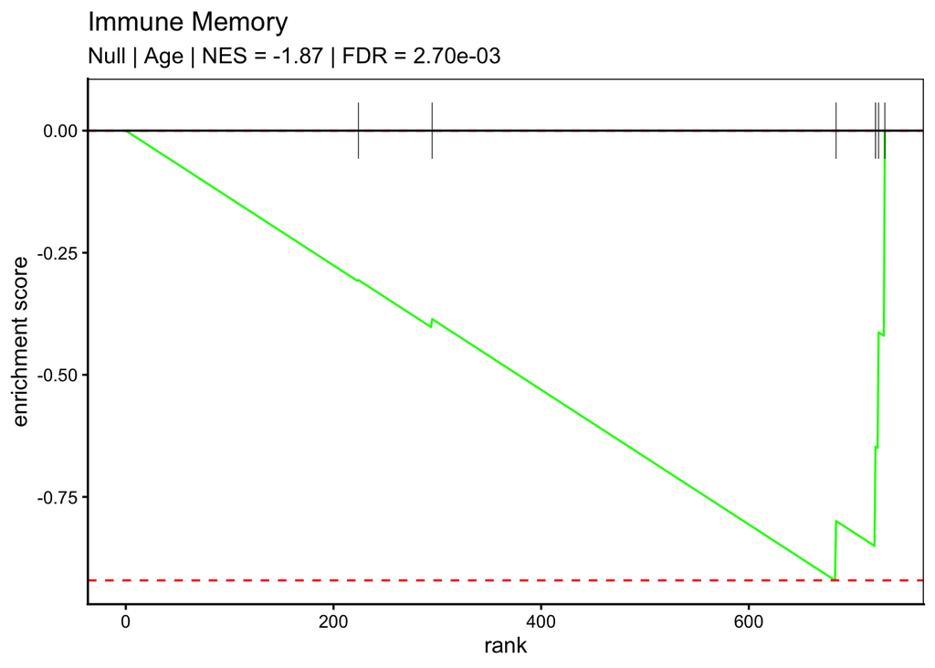

```
  PLAGE validation: Age
  PLAGE significant pathways (FDR < 0.05): 0

Analysis: Sex | Variable: Sex | Visit: W0
  Mtb_Ag | W0 | Sex: n = 32 | n after filtering: 32
  Expression matrix: 815 genes x 32 samples
  Removed 75 zero-variance genes
  Genes: 740 | FDR < 0.05: 0 | FDR < 0.01: 0 | t range: [-3.31, 2.51]
  Null | W0 | Sex: n = 31 | n after filtering: 31
  Expression matrix: 815 genes x 31 samples
  Removed 84 zero-variance genes
  Genes: 731 | FDR < 0.05: 0 | FDR < 0.01: 0 | t range: [-3.47, 3.26]
  IL1B | W0 | Sex: n = 32 | n after filtering: 32
  Expression matrix: 815 genes x 32 samples
  Removed 63 zero-variance genes
  Genes: 752 | FDR < 0.05: 0 | FDR < 0.01: 0 | t range: [-4.20, 3.47]
  LPS | W0 | Sex: n = 31 | n after filtering: 31
  Expression matrix: 815 genes x 31 samples
  Removed 69 zero-variance genes
  Genes: 746 | FDR < 0.05: 0 | FDR < 0.01: 0 | t range: [-3.20, 2.83]
  NanoTube GSEA (primary): Mtb_Ag
```

```
    Significant pathways (FDR < 0.01 and |NES| > 1): 1
  NanoTube GSEA (primary): Null
```

```
    Significant pathways (FDR < 0.01 and |NES| > 1): 4
  NanoTube GSEA (primary): IL1B
```

```
    Significant pathways (FDR < 0.01 and |NES| > 1): 2
  NanoTube GSEA (primary): LPS
```

```
    Significant pathways (FDR < 0.01 and |NES| > 1): 4
```

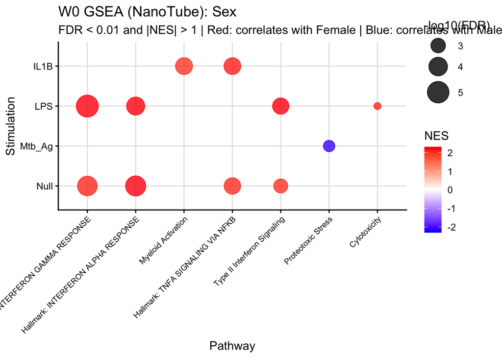

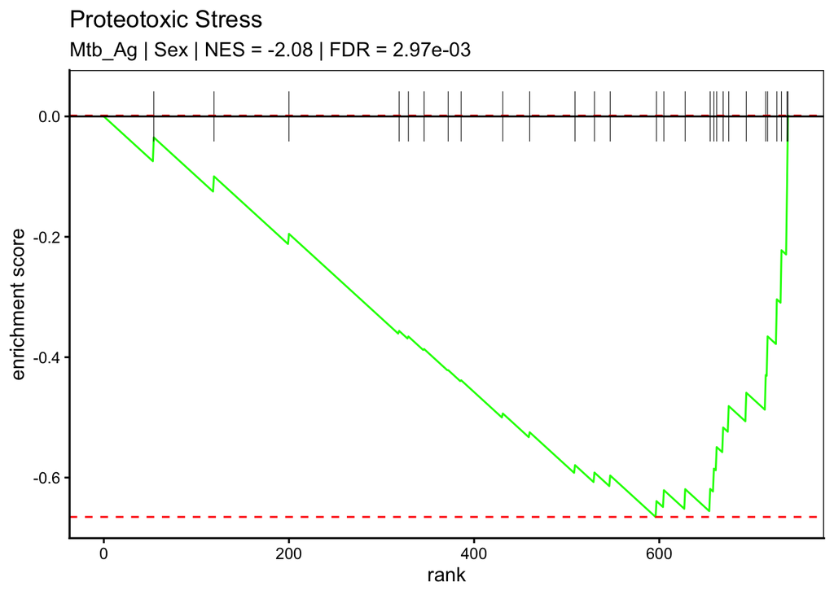

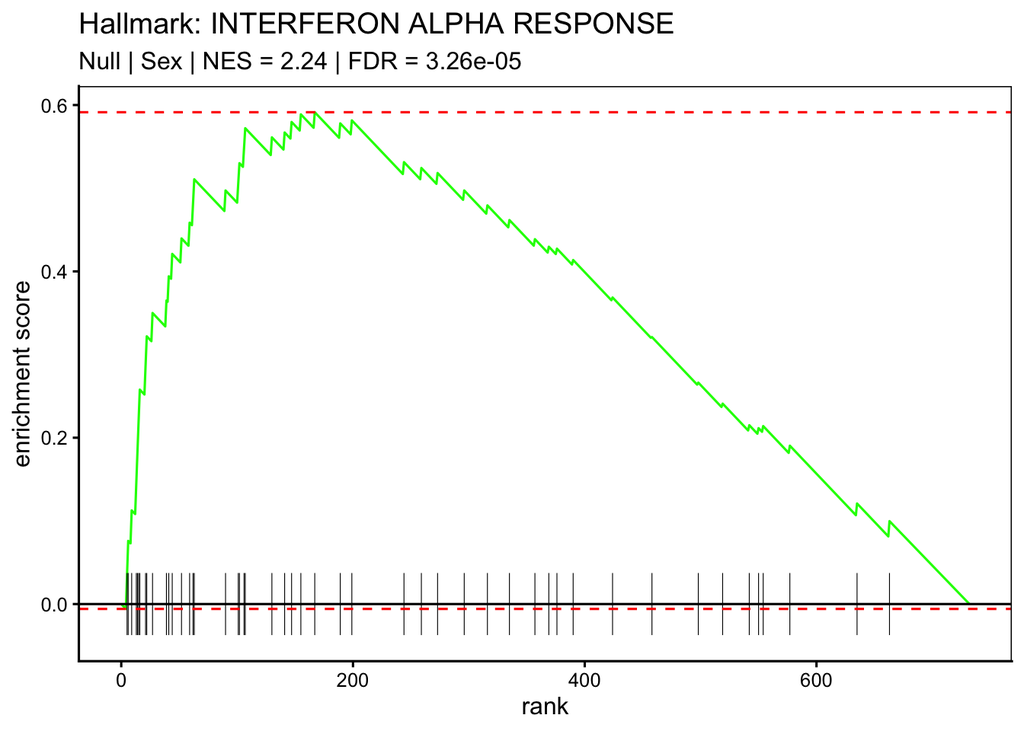

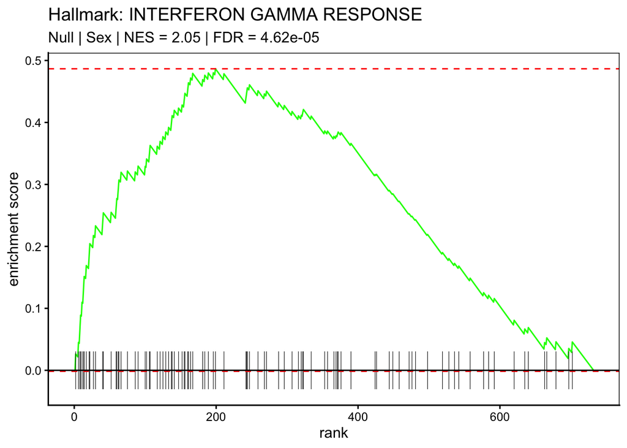

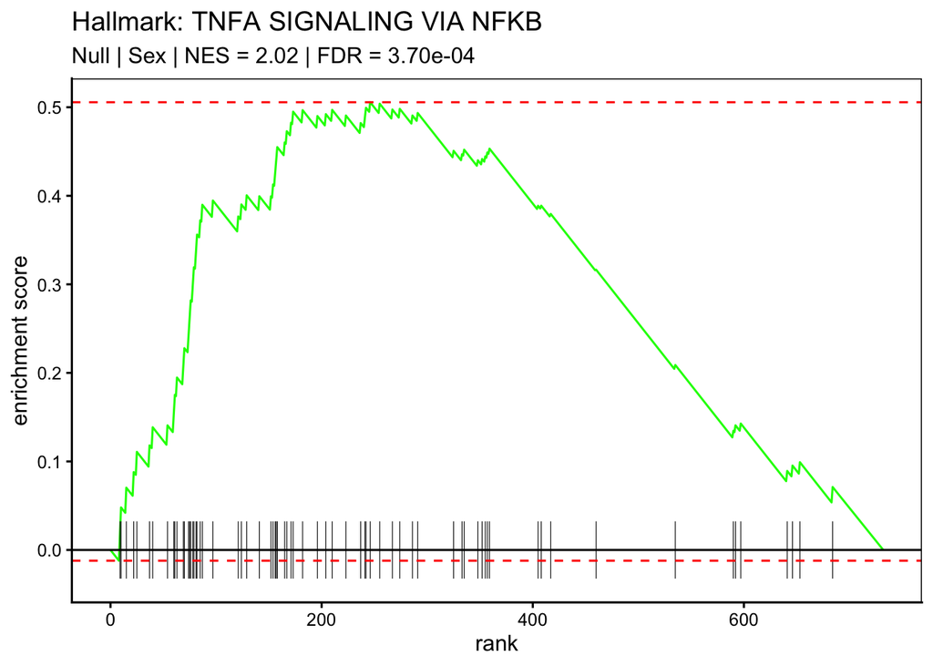

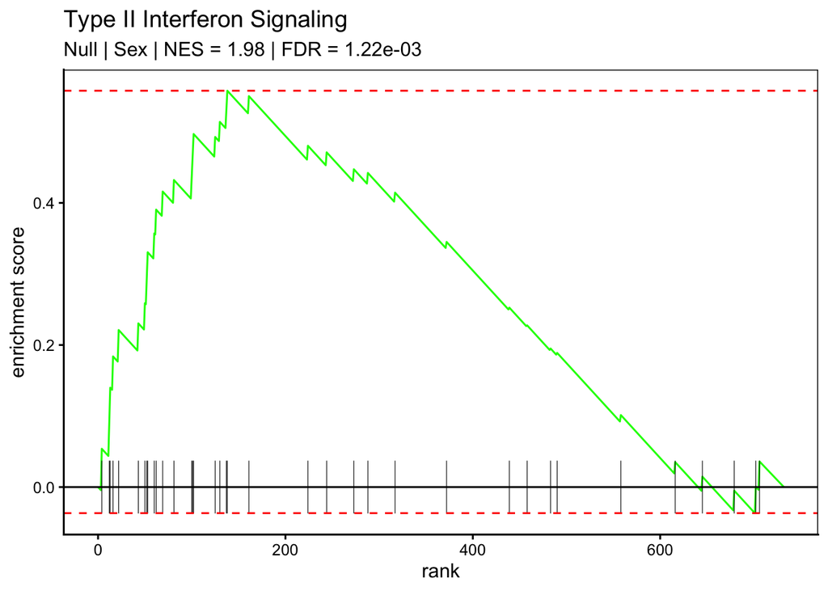

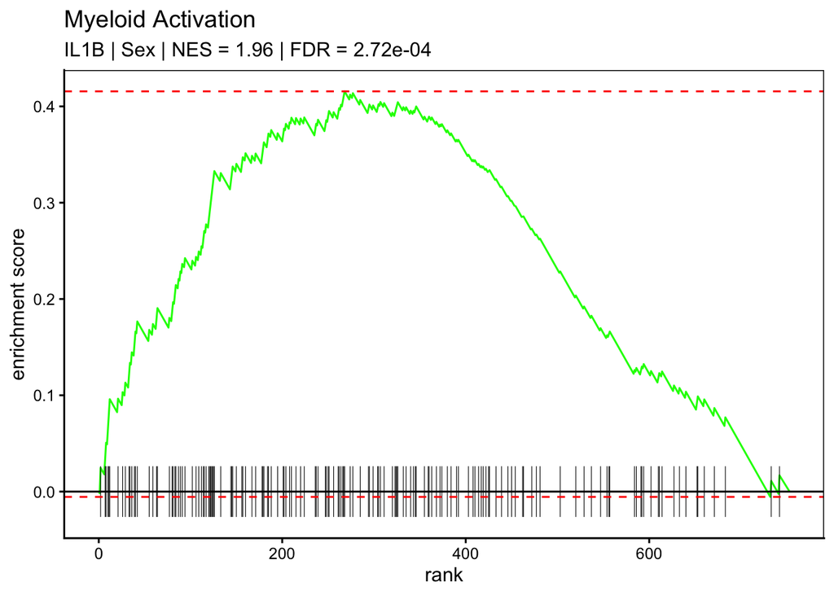

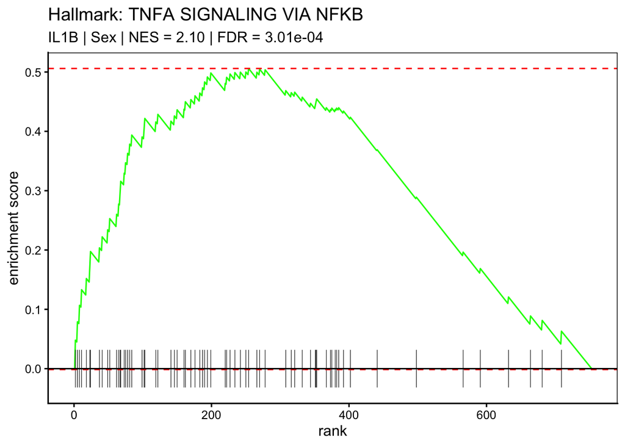

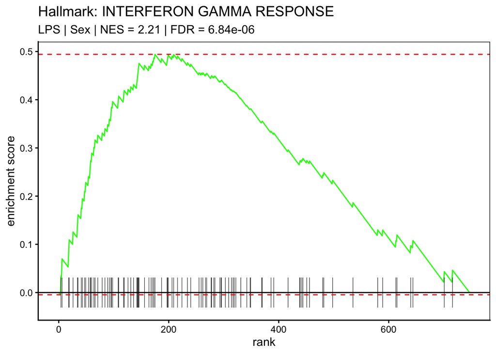

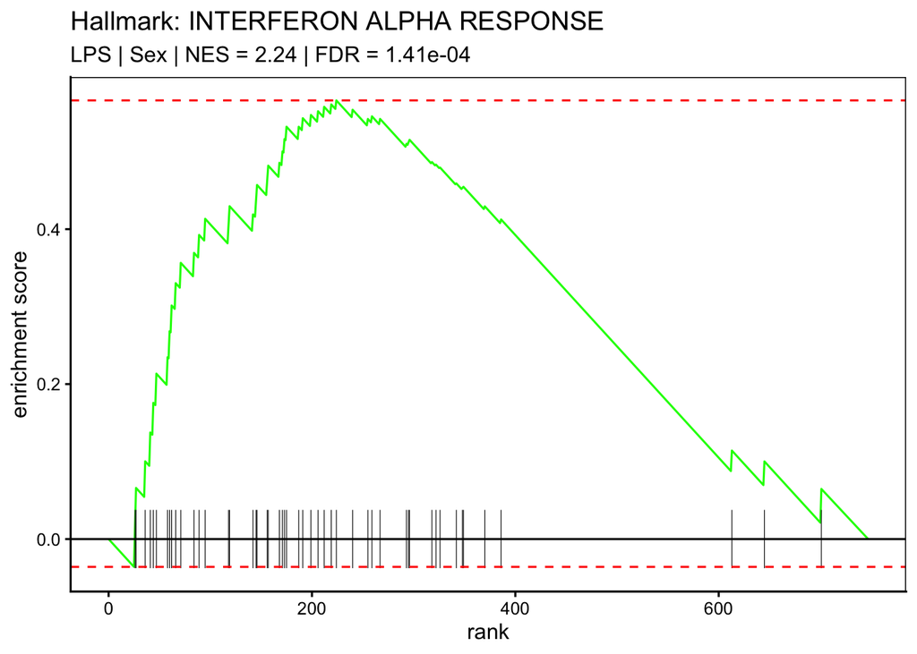

[42 more figures not shown]

```
  PLAGE validation: Lineage
  PLAGE significant pathways (FDR < 0.05): 0
```

```r
stimulations <- unique(nano_lineage_data$Stimulation)
all_analyses <- list()

for (analysis_name in names(analysis_config)) {
  config  <- analysis_config[[analysis_name]]
  out_dir <- file.path(output_main, analysis_name)

  dir.create(file.path(out_dir, "Limma"),            recursive = TRUE, showWarnings = FALSE)
  dir.create(file.path(out_dir, "NanoTube_primary"), recursive = TRUE, showWarnings = FALSE)
  dir.create(file.path(out_dir, "PLAGE_validation"), recursive = TRUE, showWarnings = FALSE)
  dir.create(file.path(out_dir, "Enrichment_plots"), recursive = TRUE, showWarnings = FALSE)

  cat(sprintf("\nAnalysis: %s | Variable: %s | Visit: %s\n",
              analysis_name, config$variable, config$visit))

  limma_fits    <- list()
  limma_results <- list()
  ranked_lists  <- list()

  for (stim in stimulations) {
    data_prep <- prepare_limma_continuous(
      data        = nano_lineage_data,
      stimulation = stim,
      visit       = config$visit,
      variable    = config$variable,
      gene_cols   = gene_cols,
      covariates  = config$covariates,
      min_n       = config$min_n
    )

    if (is.null(data_prep)) next

    limma_result <- run_limma_continuous(
      expr_matrix = data_prep$expr_matrix,
      metadata    = data_prep$metadata,
      variable    = config$variable,
      coef_name   = config$coef_name,
      covariates  = config$covariates
    )

    if (is.null(limma_result)) next

    limma_fits[[stim]]    <- limma_result$fit
    limma_results[[stim]] <- limma_result
    ranked_lists[[stim]]  <- limma_result$ranked_genes

    write_xlsx(
      limma_result$results %>%
        arrange(desc(abs(t))) %>%
        select(Gene, logFC, AveExpr, t, P.Value, adj.P.Val, B),
      file.path(out_dir, "Limma", paste0(stim, "_limma_results.xlsx"))
    )

    write_xlsx(
      data.frame(
        Gene        = names(limma_result$ranked_genes),
        t_statistic = as.numeric(limma_result$ranked_genes),
        Rank        = seq_along(limma_result$ranked_genes),
        stringsAsFactors = FALSE
      ),
      file.path(out_dir, "Limma", paste0(stim, "_ranked_genes.xlsx"))
    )
  }

  # NanoTube primary analysis
  nanotube_sig_list <- list()

  for (stim in names(limma_fits)) {
    cat(sprintf("  NanoTube GSEA (primary): %s\n", stim))

    gsea_res <- tryCatch(
      limmaToFGSEA(
        limmaResults = limma_fits[[stim]],
        gene.sets    = combined_pathways,
        min.set      = 3,
        rank.by      = "t",
        skip.first   = TRUE
      ),
      error = function(e) { message("GSEA failed: ", e$message); NULL }
    )

    if (is.null(gsea_res)) next

    coef_name <- config$coef_name
    if (is.null(gsea_res[[coef_name]])) {
      cat(sprintf("  Coefficient '%s' not found. Available: %s\n",
                  coef_name, paste(names(gsea_res), collapse = ", ")))
      next
    }

    sig_res <- gsea_res[[coef_name]] %>%
  filter(!is.na(padj), padj < 0.01, abs(NES) > 1) %>%
  mutate(Stimulation = stim)

    nanotube_sig_list[[stim]] <- sig_res

    l_edge <- tryCatch(
  fgseaToLEdge(gsea_res[[coef_name]], cutoff.type = "padj", cutoff = 0.01),
  error = function(e) NULL
)

    if (!is.null(l_edge)) {
      out_file <- file.path(out_dir, "NanoTube_primary",
                            paste0("NanoTube_GSEA_", stim, ".xlsx"))
      tryCatch(
        fgseaPostprocessingXLSX(
          genesetResults = gsea_res[[coef_name]],
          leadingEdge    = l_edge,
          limmaResults   = limma_fits[[stim]],
          join.threshold = 0.5,
          filename       = out_file
        ),
        error = function(e) message("Postprocessing failed: ", e$message)
      )
    }

    cat(sprintf("    Significant pathways (FDR < 0.01 and |NES| > 1): %d\n", nrow(sig_res)))
  }

  nanotube_sig <- bind_rows(nanotube_sig_list)

  if (nrow(nanotube_sig) > 0) {
    nanotube_sig %>%
      mutate(leadingEdge = sapply(leadingEdge, paste, collapse = ";")) %>%
      write_xlsx(file.path(out_dir, "NanoTube_primary",
                           "Significant_pathways_all_stim.xlsx"))

    nanotube_plot_data <- nanotube_sig %>%
      mutate(
        pathway_short = ifelse(
          grepl("^HALLMARK_", pathway),
          paste0("Hallmark: ", gsub("_", " ", gsub("^HALLMARK_", "", pathway))),
          gsub("_", " ", pathway)
        ),
        padj_plot = padj
      )

    nt_subtitle <- paste0(
  "FDR < 0.01 and |NES| > 1 | Red: correlates with ", config$positive_label,
  " | Blue: correlates with ",                         config$negative_label
)

plot_bubble(
  plot_data = nanotube_plot_data,
  title     = paste("W0 GSEA (NanoTube):", config$label),
  subtitle  = nt_subtitle,
  save_path = out_dir,
  filename  = paste0(analysis_name, "_NanoTube_bubble_plot.pdf"),
  fill_col  = "NES",
  fill_name = "NES"
)

    for (stim in names(ranked_lists)) {
      top_sig <- nanotube_sig %>%
        filter(Stimulation == stim) %>%
        arrange(padj) %>%
        head(config$top_n_enrich)

      if (nrow(top_sig) == 0) next

      for (i in seq_len(nrow(top_sig))) {
        pw_name <- top_sig$pathway[i]
        if (is.null(combined_pathways[[pw_name]])) next

        p_enrich <- plotEnrichment(combined_pathways[[pw_name]],
                                   ranked_lists[[stim]]) +
          labs(
            title = ifelse(
              grepl("^HALLMARK_", pw_name),
              paste0("Hallmark: ", gsub("_", " ", gsub("^HALLMARK_", "", pw_name))),
              gsub("_", " ", pw_name)
            ),
            subtitle = sprintf("%s | %s | NES = %.2f | FDR = %.2e",
                               stim, config$variable,
                               top_sig$NES[i], top_sig$padj[i])
          ) +
          theme_classic(base_size = 12) +
          theme(panel.border = element_rect(color = "black", fill = NA))

        print(p_enrich)

        safe_name <- substr(gsub("[^a-zA-Z0-9]", "_", pw_name), 1, 50)
        ggsave(
          file.path(out_dir, "Enrichment_plots",
                    paste0(stim, "_", safe_name, "_enrichment.pdf")),
          plot = p_enrich, width = 7, height = 5, units = "in"
        )
      }
    }
  }

  # PLAGE validation
  cat(sprintf("\n  PLAGE validation: %s\n", analysis_name))

  plage_results <- list()

  for (stim in stimulations) {
    results <- bind_rows(lapply(names(combined_pathways), function(pw) {
      run_plage_continuous(
        data         = nano_lineage_data,
        stimulation  = stim,
        visit        = config$visit,
        variable     = config$variable,
        pathway_name = pw,
        gene_set     = combined_pathways[[pw]],
        min_n        = config$min_n
      )
    }))

    if (!is.null(results) && nrow(results) > 0) {
      results <- results %>%
        mutate(P_adj = p.adjust(P_value, method = "fdr")) %>%
        arrange(P_adj)
      plage_results[[stim]] <- results
    }
  }

  all_plage <- bind_rows(plage_results)

  sig_plage <- all_plage %>%
    filter(!is.na(P_adj), P_adj < 0.05) %>%
    arrange(P_adj)

  cat(sprintf("  PLAGE significant pathways (FDR < 0.05): %d\n", nrow(sig_plage)))

  write_xlsx(all_plage, file.path(out_dir, "PLAGE_validation",
                                  "PLAGE_all_results.xlsx"))
  write_xlsx(sig_plage, file.path(out_dir, "PLAGE_validation",
                                  "PLAGE_significant_FDR05.xlsx"))

  if (nrow(sig_plage) > 0) {
    plage_plot_data <- sig_plage %>%
      mutate(
        pathway_short = ifelse(
          grepl("^HALLMARK_", Pathway),
          paste0("Hallmark: ", gsub("_", " ", gsub("^HALLMARK_", "", Pathway))),
          gsub("_", " ", Pathway)
        ),
        padj_plot = P_adj
      )

    plage_subtitle <- paste0(
  "FDR < 0.05 | Red: higher pathway activity in ",  config$positive_label,
  " | Blue: higher pathway activity in ",            config$negative_label
)

plot_bubble(
  plot_data = plage_plot_data,
  title     = paste("W0 PLAGE validation:", config$label),
  subtitle  = plage_subtitle,
  save_path = out_dir,
  filename  = paste0(analysis_name, "_PLAGE_bubble_plot.pdf"),
  fill_col  = "Score_cor",
  fill_name = "Pearson r"
)
  }

  # Cross-validation
  if (nrow(nanotube_sig) > 0 && nrow(sig_plage) > 0) {
    nt_slim <- nanotube_sig %>%
      select(pathway, Stimulation, NES, padj) %>%
      rename(NanoTube_NES = NES, NanoTube_padj = padj)

    plage_slim <- sig_plage %>%
      select(Pathway, Stimulation, Score_cor, P_adj) %>%
      rename(pathway = Pathway, PLAGE_cor = Score_cor, PLAGE_padj = P_adj)

    confirmed <- inner_join(nt_slim, plage_slim, by = c("pathway", "Stimulation")) %>%
      arrange(NanoTube_padj)

    n_nanotube_only <- nrow(nanotube_sig) - nrow(confirmed)
    n_plage_only    <- nrow(sig_plage)    - nrow(confirmed)

    cat(sprintf(
      "  NanoTube only: %d | PLAGE only: %d | Both: %d\n",
      n_nanotube_only, n_plage_only, nrow(confirmed)
    ))

    overlap_summary <- data.frame(
      Analysis      = analysis_name,
      Variable      = config$variable,
      NanoTube_n    = nrow(nanotube_sig),
      PLAGE_n       = nrow(sig_plage),
      Confirmed_n   = nrow(confirmed),
      NanoTube_only = n_nanotube_only,
      PLAGE_only    = n_plage_only,
      stringsAsFactors = FALSE
    )

    write_xlsx(overlap_summary, file.path(out_dir, "Method_overlap_summary.xlsx"))
    write_xlsx(confirmed,       file.path(out_dir, "Confirmed_pathways_both_methods.xlsx"))

    if (nrow(confirmed) > 0) {
      confirmed_plot <- confirmed %>%
        mutate(
          pathway_short = ifelse(
            grepl("^HALLMARK_", pathway),
            paste0("Hallmark: ", gsub("_", " ", gsub("^HALLMARK_", "", pathway))),
            gsub("_", " ", pathway)
          ),
          Stimulation = factor(Stimulation,
                               levels = c("Null", "Mtb_Ag", "LPS", "IL1B"))
        )

      pathway_order_c <- confirmed_plot %>%
        arrange(NanoTube_padj) %>%
        pull(pathway_short) %>%
        unique()

      confirmed_plot <- confirmed_plot %>%
        mutate(pathway_short = factor(pathway_short, levels = pathway_order_c))

      nes_limit <- ceiling(max(abs(confirmed_plot$NanoTube_NES), na.rm = TRUE) * 10) / 10

      p_conf <- ggplot(
          confirmed_plot,
          aes(x = pathway_short, y = Stimulation,
              size = -log10(NanoTube_padj), color = NanoTube_NES)
        ) +
        geom_point(alpha = 0.8) +
        scale_color_gradient2(
          low      = "blue",
          mid      = "white",
          high     = "red",
          midpoint = 0,
          limits   = c(-nes_limit, nes_limit),
          name     = "NES\n(NanoTube)"
        ) +
        scale_size_continuous(range = c(3, 10), name = "-log10(FDR)\n(NanoTube)") +
        scale_x_discrete(drop = FALSE) +
        scale_y_discrete(drop = FALSE) +
        labs(
  title    = paste("W0 Confirmed pathways:", config$label),
  subtitle = paste0(
    "FDR < 0.05 in both NanoTube and PLAGE | Red: correlates with ",
    config$positive_label,
    " | Blue: correlates with ",
    config$negative_label
  ),
          x = "Pathway",
          y = "Stimulation"
        ) +
        theme_classic(base_size = 12) +
        theme(
          axis.text.x      = element_text(angle = 45, hjust = 1,
                                          color = "black", size = 8),
          axis.text.y      = element_text(color = "black"),
          panel.grid.major = element_line(color = "gray90"),
          legend.position  = "right"
        )

      print(p_conf)

      ggsave(
        file.path(out_dir, paste0(analysis_name, "_Confirmed_bubble_plot.pdf")),
        plot = p_conf, width = 10, height = 6, units = "in"
      )
    }
  }

  all_analyses[[analysis_name]] <- list(
    limma_results        = limma_results,
    ranked_lists         = ranked_lists,
    nanotube_significant = nanotube_sig,
    plage_significant    = sig_plage
  )
}
```